# Analysis of bike theft incidents in NYC

### Motivation

The dataset we chose includes all valid felony, misdemeanor, and violation crimes reported to the New York City Police Department (NYPD) from 2006 to the end of last year (2019). For each report, the police department documented, among other details, the date and time of the crime, description of the offense, indication of whether the crime was completed or interrupted, the name of the borough with specific longitude and latitude coordinates.

The reason we chose this dataset was that it included all type of data. We wanted to be able to showcase both time series plots as well as maps, in order to use as much of the tools we learned in the course.

At the end of this notebook we aim to get a better understanding of the dataset but mostly of how different tools can give you very different insights from the same data source.

### Basic stats

We had a vague idea of the parts of the dataset that were interesting to us. The human aspect was what drew us to it, so we kept all related columns as well as all column relating to the time and space of the incident. The dataset has 80496 entries with 36 total columns. It contained a lot of technical details concerning code and precinct policies that we were not interested in, but kept either way.

The most helpfull part of the preprocessing was understanding what all the column titles ment. After changing the names, working with the dataframe was much easier. We didn't want to "clean" all the NaN or empty cells as we were gonna approach the same data from different prospectives and we didn't want to deprive ourselves of entry points. For example, even if there was no "suspect sex" noted for a specific entry we would still use it when plotting the data by time. For that reason we did minor cleaning of the specific columns we needed for each visual.

### Data Analysis

Now let's start with the technical details. Following are the cells with comments to explain all the steps we did to create our visualizations.

```python
# We used many different visualization techniques and we needed to save every interactive element as an html file, which gave rise to some challenges.
from folium.plugins import HeatMapWithTime
import matplotlib.pyplot as plt
import pandas as pd
import plotly.graph_objects as go
from matplotlib.colors import LinearSegmentedColormap
import plotly.express as px
import panel as pn
from folium import Map
```

```python
# adding our dataset
df = pd.read_csv('NYPD_Bike_Theft_Data.csv')
```

```python
# Fixing column names to more user friendly ones
renamed_columns = {
    'CMPLNT_NUM': 'complaint_id',
    'CMPLNT_FR_DT': 'start_date',
    'CMPLNT_FR_TM': 'start_time',
    'CMPLNT_TO_DT': 'end_date',
    'CMPLNT_TO_TM': 'end_time',
    'ADDR_PCT_CD': 'precinct_code',
    'RPT_DT': 'report_date',
    'KY_CD': 'offense_code',
    'OFNS_DESC': 'offense_description',
    'PD_CD': 'internal_code',
    'PD_DESC': 'internal_description',
    'CRM_ATPT_CPTD_CD': 'attempt_completed',
    'LAW_CAT_CD': 'law_category',
    'BORO_NM': 'borough',
    'LOC_OF_OCCUR_DESC': 'location_detail',
    'PREM_TYP_DESC': 'premise_description',
    'JURIS_DESC': 'jurisdiction_description',
    'JURISDICTION_CODE': 'jurisdiction_code',
    'PARKS_NM': 'park_name',
    'HADEVELOPT': 'nycha_development',
    'HOUSING_PSA': 'housing_psa',
    'X_COORD_CD': 'x_coord',
    'Y_COORD_CD': 'y_coord',
    'SUSP_AGE_GROUP': 'suspect_age_group',
    'SUSP_RACE': 'suspect_race',
    'SUSP_SEX': 'suspect_sex',
    'TRANSIT_DISTRICT': 'transit_district',
    'Latitude': 'latitude',
    'Longitude': 'longitude',
    'Lat_Lon': 'lat_lon',
    'PATROL_BORO': 'patrol_borough',
    'STATION_NAME': 'station_name',
    'VIC_AGE_GROUP': 'victim_age_group',
    'VIC_RACE': 'victim_race',
    'VIC_SEX': 'victim_sex'
}
df.rename(columns=renamed_columns, inplace=True)
```

```python
# Cleaning up the sex to keep only three options
df['victim_sex'] = df['victim_sex'].apply(lambda x: x if x in ['M', 'F'] else 'Others')
df['suspect_sex'] = df['suspect_sex'].apply(lambda x: x if x in ['M', 'F'] else 'Others')
# Adding a Month column, we will use it in out temporal analysis.
df['month'] = pd.to_datetime(df['report_date'], errors='coerce').dt.month
```

## The Crime

In this part we add our visualizations that were part of the exploratory analysis but were not insightfull enough to dive in deeper.

First a Piechart of the distribution of offense discriptions.

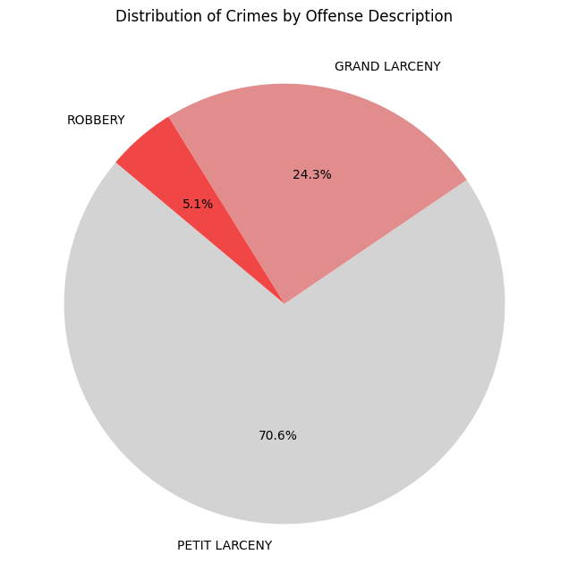

```python
# Calculate the counts of each offense description
offense_counts = df['offense_description'].value_counts()

# Create a custom colormap from light grey to red - to feed with the red theme of the website
cmap = LinearSegmentedColormap.from_list("grey_to_red", ["lightgrey", "red"])
colors = [cmap(i / len(offense_counts)) for i in range(len(offense_counts))]

# Create a pie chart for the distribution of crimes by offense description
plt.figure(figsize=(8, 8))
plt.pie(offense_counts.values, labels=offense_counts.index, autopct='%1.1f%%', startangle=140, colors=colors)

# Add a title
plt.title('Distribution of Crimes by Offense Description')

# Show the plot
plt.savefig("my_pie.png")
plt.show()
```

Following by a bar chart of completed vs attempted incidents.

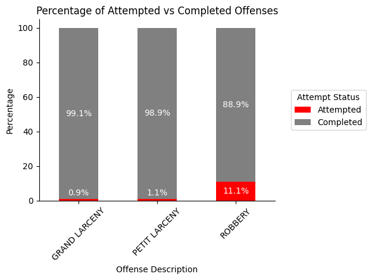

```python
# Calculate the count of attempted and completed offenses grouped by offense description
# Filter out null or invalid values
df_filtered = df[df['attempt_completed'].isin(['COMPLETED', 'ATTEMPTED'])]

# Group by only valid categories
relation_data = df_filtered.groupby(['offense_description', 'attempt_completed']).size().unstack(fill_value=0)

# Calculate the percentage for each category
relation_data_percentage = relation_data.div(relation_data.sum(axis=1), axis=0) * 100

# Set the figure size
plt.figure(figsize=(20, 10))

# Create a bar plot for percentages
ax = relation_data_percentage.plot(
    kind='bar',
    stacked=True,
    color=['red','grey'],
    edgecolor='none'
)
ax.spines['top'].set_visible(False)
ax.spines['right'].set_visible(False)
ax.spines['bottom'].set_visible(True)
ax.spines['left'].set_visible(True)

# Add percentages on top of the bars
for container in ax.containers:
    for bar in container:
        height = bar.get_height()
        if height > 0:
            if height < 10:  # Small bar, show label above
                ax.text(
                    bar.get_x() + bar.get_width() / 2,
                    bar.get_y() + height + 1,  # Slightly above the bar
                    f'{height:.1f}%',
                    ha='center',
                    va='bottom',
                    fontsize=10,
                    color='white'
                )
            else:  # Normal-sized bar, label centered inside
                ax.text(
                    bar.get_x() + bar.get_width() / 2,
                    bar.get_y() + height / 2,
                    f'{height:.1f}%',
                    ha='center',
                    va='center',
                    fontsize=10,
                    color='white'
                )


# Add labels and title
plt.title("Percentage of Attempted vs Completed Offenses")
plt.xlabel("Offense Description")
plt.ylabel("Percentage")

# Place the legend outside the plot
plt.legend(
    title="Attempt Status",
    labels=["Attempted", "Completed"],
    bbox_to_anchor=(1.05, 0.5),
    loc='center left'
)

plt.xticks(rotation=45)
plt.yticks()

# Show the plot
plt.tight_layout()
plt.savefig("attempt.png")
plt.show()
```

## The People

We now start our more intriquet analysis by creating two Sankey charts, one for the victims and one for the suspects. We chose the Sankey diagram as it's more compact and we could easily show all three characteristics of each individual.

```python
# Filter out rows where victim_age_group or victim_race is 'UNKNOWN'
df2 = df[df['victim_age_group'] != 'UNKNOWN']
df2= df2[df2['victim_race'] != 'UNKNOWN']

# Filter out rows where victim_age_group or victim_race is 'UNKNOWN'
df2 = df2[df2['suspect_age_group'] != 'UNKNOWN']
df2 = df2[df2['suspect_race'] != 'UNKNOWN']

# Define the list of unwanted age groups
unwanted_age_groups = ['(null)', '-2', '-971', '1013', '929', '943', '971', '957']

# Filter the dataframe
df2 = df2[~df2['victim_age_group'].isin(unwanted_age_groups)]
df2 = df2[df2['victim_race'] != '(null)']

# Sort victim_age_group in the specified order
age_group_order = reversed(['<18', '18-24', '25-44', '45-64', '65+'])
df2['victim_age_group'] = pd.Categorical(df2['victim_age_group'], categories=age_group_order, ordered=True)

# Prepare the data for the Sankey diagram
victim_labels = list(df2['victim_sex'].unique()) + list(df2['victim_race'].unique()) + list(df2['victim_age_group'].unique())
victim_label_to_index = {label: i for i, label in enumerate(victim_labels)}

# Create source and target indices
link_counts = {'source': [], 'target': [], 'value': []}

# Add links between victim_sex and victim_race
for sex in df2['victim_sex'].unique():
    for race in df2['victim_race'].unique():
        count = len(df2[(df2['victim_sex'] == sex) & (df2['victim_race'] == race)])
        if count > 0:
            link_counts['source'].append(victim_label_to_index[sex])
            link_counts['target'].append(victim_label_to_index[race])
            link_counts['value'].append(count)

# Add links between victim_race and victim_age_group
for race in df2['victim_race'].unique():
    for age_group in df2['victim_age_group'].unique():
        count = len(df2[(df2['victim_race'] == race) & (df2['victim_age_group'] == age_group)])
        if count > 0:
            link_counts['source'].append(victim_label_to_index[race])
            link_counts['target'].append(victim_label_to_index[age_group])
            link_counts['value'].append(count)

# Define colors for links compatible with our site
link_colors = ["rgba(170, 10, 10, 0.5)" for _ in range(len(link_counts['value']))]

# Create the Sankey diagram with colors
fig = go.Figure(data=[go.Sankey(
    node=dict(
        pad=15,
        thickness=20,
        line=dict(color="black", width=0.5),
        label=victim_labels,
        color="lightgrey"
    ),
    link=dict(
        source=link_counts['source'],
        target=link_counts['target'],
        value=link_counts['value'],
        color=link_colors
    )
)])

# Add title and display the diagram
fig.update_layout(title_text="Sankey Diagram of Victim Information (Sex, Race, Age Group)")
fig.show()

# Export the Sankey diagram as an HTML file
fig.write_html("sankey_diagram_victim_information.html")
```

[interactive chart not shown]

```python
# Define the list of unwanted age groups
unwanted_age_groups2 = ['(null)', '2019','2013',2019,2013]

# Filter the dataframe
df2 = df2[~df2['suspect_age_group'].isin(unwanted_age_groups2)]
df2 = df2[df2['victim_race'] != '(null)']

# Prepare the data for the Sankey diagram
suspect_labels = list(df2['suspect_sex'].unique()) + list(df2['suspect_race'].unique()) + list(df2['suspect_age_group'].unique())
suspect_label_to_index = {label: i for i, label in enumerate(suspect_labels)}

# Create source and target indices
suspect_link_counts = {'source': [], 'target': [], 'value': []}

# Add links between suspect_sex and suspect_race
for sex in df2['suspect_sex'].unique():
    for race in df2['suspect_race'].unique():
        count = len(df2[(df2['suspect_sex'] == sex) & (df2['suspect_race'] == race)])
        if count > 0:
            suspect_link_counts['source'].append(suspect_label_to_index[sex])
            suspect_link_counts['target'].append(suspect_label_to_index[race])
            suspect_link_counts['value'].append(count)

# Add links between suspect_race and suspect_age_group
for race in df2['suspect_race'].unique():
    for age_group in df2['suspect_age_group'].unique():
        count = len(df2[(df2['suspect_race'] == race) & (df2['suspect_age_group'] == age_group)])
        if count > 0:
            suspect_link_counts['source'].append(suspect_label_to_index[race])
            suspect_link_counts['target'].append(suspect_label_to_index[age_group])
            suspect_link_counts['value'].append(count)

# Define colors for links (optional, can use node colors or a gradient)
suspect_link_colors = ["rgba(170, 10, 10, 0.5)" for _ in range(len(suspect_link_counts['value']))]

# Create the Sankey diagram with colors
fig = go.Figure(data=[go.Sankey(
    node=dict(
        pad=15,
        thickness=20,
        line=dict(color="black", width=0.5),
        label=suspect_labels,
        color="lightgrey"
    ),
    link=dict(
        source=suspect_link_counts['source'],
        target=suspect_link_counts['target'],
        value=suspect_link_counts['value'],
        color=suspect_link_colors
    )
)])

# Add title and display the diagram
fig.update_layout(title_text="Sankey Diagram of Suspect Information (Sex, Race, Age Group)")
fig.show()

# Export the Sankey diagram as an HTML file
fig.write_html("sankey_diagram_suspect_information.html")
```

[interactive chart not shown]

After looking at the diagrams we noticed a few comparisons between the victims and the suspects. To highlight those observations we then created a correlation matrix, with the added functionality of choosing which characteristic to compare each time.

```python
pn.extension('plotly')

# Separate suspect and victim features
suspect_label_map = {
    'Suspect Race': 'suspect_race',
    'Suspect Sex': 'suspect_sex',
    'Suspect Age Group': 'suspect_age_group',
}

victim_label_map = {
    'Victim Race': 'victim_race',
    'Victim Sex': 'victim_sex',
    'Victim Age Group': 'victim_age_group',
}
reverse_suspect_map = {v: k for k, v in suspect_label_map.items()}
reverse_victim_map = {v: k for k, v in victim_label_map.items()}

# Create separate dropdowns
suspect_selector = pn.widgets.Select(name='Suspect Characteristic', options=suspect_label_map, value='suspect_race')
victim_selector = pn.widgets.Select(name='Victim Characteristic', options=victim_label_map, value='victim_race')

# Function to update the plot
@pn.depends(suspect_selector, victim_selector)
def update_plot(suspect_feature, victim_feature):
    race_labels = {
        'AMERICAN INDIAN/ALASKAN NATIVE':'AMERICAN INDIAN',
        'BLACK': 'Black',
        'WHITE': 'White',
        'ASIAN / PACIFIC ISLANDER': 'Asian',
        'WHITE HISPANIC': 'W-Hispanic',
        'BLACK HISPANIC': 'B-Hispanic'
    }

    contingency = pd.crosstab(df2[victim_feature], df2[suspect_feature])

    x_labels = [race_labels.get(val, val) for val in contingency.columns] if 'race' in suspect_feature else contingency.columns
    y_labels = [race_labels.get(val, val) for val in contingency.index] if 'race' in victim_feature else contingency.index
    x_title = reverse_suspect_map[suspect_feature]
    y_title = reverse_victim_map[victim_feature]

    fig = px.imshow(
        contingency.values,
        text_auto=True,
        labels=dict(x=x_title, y=y_title, color="Count"),
        x=x_labels,
        y=y_labels,
        color_continuous_scale="Reds",
        title=f'Correlation: {y_title} vs {x_title}'
    )

    fig.update_layout(
        width=500,
        height=400,
        autosize=False,
        margin=dict(t=60, l=80, r=40, b=60)
    )
    return pn.pane.Plotly(fig, config={'responsive': True})

# Combine widgets and plot
app = pn.Column(
    "# Interactive Correlation Heatmap",
    pn.Row(victim_selector, suspect_selector),
    update_plot
)

# Save to interactive HTML
app.save("correlation_matrix.html", embed=True)
```

## The Time

Moving on to the temporal element of the data, we again created an interactive plot. The bar plot shown on the site is a more condensed version of all the plots we did during the exploratory analysis. We chose to not keep all the individual plots we created while first looking at the data so as to not repeat ourselves throughout the notebook.

```python
pn.extension('plotly')

# Create time-based columns if not already present
df['Hour of Day'] = df['start_time'].str[:2].astype(int)
df['start_date'] = pd.to_datetime(df['start_date'], errors='coerce')
df['Day of Month'] = df['start_date'].dt.day
df['Month of Year'] = df['start_date'].dt.month_name()
df['Day of Week'] = df['start_date'].dt.day_name()

# Map dropdown labels to column names
time_options = {
    'Hour of Day': 'Hour of Day',
    'Day of Week': 'Day of Week',
    'Day of Month': 'Day of Month',
    'Month of Year': 'Month of Year'
}

# Create the dropdown widget
time_selector = pn.widgets.Select(name='Group by Time', options=list(time_options.keys()), value='Hour of Day')

# Define the plotting function
@pn.depends(time_selector)
def update_time_plot(time_choice):
    time_column = time_options[time_choice]

    # Aggregate total crime counts by the selected time column
    counts = df[time_column].value_counts().sort_index()

    # For better ordering of days/months
    if time_choice == 'Day of Week':
        day_order = ['Monday', 'Tuesday', 'Wednesday', 'Thursday', 'Friday', 'Saturday', 'Sunday']
        counts = counts.reindex(day_order)
    elif time_choice == 'Month of Year':
        month_order = ['January', 'February', 'March', 'April', 'May', 'June',
                       'July', 'August', 'September', 'October', 'November', 'December']
        counts = counts.reindex(month_order)

    # Create bar plot
    fig = px.bar(
        x=counts.index,
        y=counts.values,
        labels={'x': time_choice, 'y': 'Number of Crimes'},
        title=f'Crimes by {time_choice}'
    )

    fig.update_traces(
    marker=dict(color='red', opacity=0.8)
    )

    fig.update_layout(
        width=600,
        height=400,
        xaxis_title=time_choice,
        yaxis_title="Number of Crimes",
        uniformtext_minsize=8,
        uniformtext_mode='hide',
        plot_bgcolor='rgba(0,0,0,0)',
        paper_bgcolor='rgba(0,0,0,0)'
    )


    return pn.pane.Plotly(fig, config={'responsive': True})

# Combine into a Panel app
app = pn.Column(
    "# Crime Distribution by Time",
    time_selector,
    update_time_plot
)

# Save as interactive HTML
app.save("crimes_by_time.html", embed=True)
```

Then we added the information of the boroughs to intoduce a spatial element.

```python
# Filter out rows with missing patrol_borough
df = df[df['borough'] != '(null)']


# Truncate to monthly level
df['Month'] = df['start_date'].dt.to_period('M').dt.to_timestamp()
df = df[df['Month'] >= '2006-01-01']

# Group by patrol_borough and Month
grouped = df.groupby(['borough', 'Month']).size().reset_index(name='Theft_Counts')

# Create interactive line plot
fig = px.line(
    grouped,
    x='Month',
    y='Theft_Counts',
    color='borough',
    title='Bike Theft Reports Over Time by Borough',
    labels={'Month': 'start_date', 'Theft_Count': 'Total Thefts'},
    markers=True
)

# Make background transparent
fig.update_layout(
    plot_bgcolor='rgba(0,0,0,0)',   # transparent plot area
    paper_bgcolor='rgba(0,0,0,0)',  # transparent outer background
    xaxis_title='Time',
    yaxis_title='Number of Incidents'
)
# Set fixed y-axis and x-axis ranges
y_min = grouped['Theft_Counts'].min()
y_max = grouped['Theft_Counts'].max()
x_min = grouped['Month'].min()
x_max = grouped['Month'].max()

fig.update_layout(
    yaxis=dict(range=[y_min, y_max]),
    xaxis=dict(range=[x_min, x_max])
)
fig.update_layout(legend_title_text='Borough Name')

fig.write_html("bike_thefts_time_plot2.html", full_html=False, include_plotlyjs='cdn',config={'displayModeBar': False})
fig.show()
```

[interactive chart not shown]

## The Place

We finsih up our analysis with a moving map! The best way to showcase spatial elements is naturally a map. Continuing on the trend of combining the time and space of an entry for a more compelte picture, we created gif of a heatmap with the total reports for every month every year.

```python
# Create a new column 'YearMonth' by combining 'year' and 'month'
df['year'] = df['start_date'].dt.year
df['year'] = df['year'].fillna(0).astype(int)
df['YearMonth'] = df['year'].astype(str) + '-' + df['month'].astype(str).str.zfill(2)
```

```python
df = df[df['year'] >= 2006]
```

```python
# Set the map size to width=1000 and height=600
heatmap_map = Map(location=[40.7128, -74.0060], zoom_start=12, width=1000, height=600)
# Group the data by YearMonth and calculate the average latitude, longitude, and count of crimes
crime_data = df.groupby('YearMonth').agg({'latitude': 'mean', 'longitude': 'mean', 'complaint_id': 'count'}).reset_index()

# Prepare data for HeatMapWithTime
heatmap_data_by_time = []
for year_month in crime_data['YearMonth'].unique():
    filtered_data = df[df['YearMonth'] == year_month]
    heatmap_data_by_time.append(
        filtered_data[['latitude', 'longitude']].dropna().values.tolist()
    )

# Add HeatMapWithTime layer
HeatMapWithTime(
    data=heatmap_data_by_time,
    index=crime_data['YearMonth'].tolist(),
    radius=10,
    auto_play=True,
    max_opacity=0.8
).add_to(heatmap_map)

# Display the map
heatmap_map

# Export the map as an HTML file
heatmap_map.save("heatmap_with_time3.html")
```

### Data Story Genre

- Visual Narrative
  - We kept a Consistent Visual Platform, as throughout the site, we maintain a coherent visual style, structure, and design.
  - We added animated transitions to signal the beginning of a new chapter of our analysis.
- Narrative Structure
  - We followed a very strict author driven structure with linear ordering.
  - We added quite a few interactive elements.
    - Hovering reveals additional information in most of our visuals.
    - Two graphs allow for direct selection of the elements displaued in the axis.
    - Our Line graphs allows for specific selection of one of the lines from the legend to highlight.
  - All visuals have titles and clear discriptions of the axis. Each section also comes with its own headline.
  - We summarize our most important observations at the end of the article.

### Visualizations

The visuals were the main focus of our project and we chose them in a way so that we have a diverse selection of visualization techniques.

### Discussion

We believe we used a variety of different visualization techniques and were able to get a few insightful observations out of our dataset.

While working on the visuals, we kept having new ideas of different ways to showcase a trend, like comparing completion rates with neighbourhoods to maybe get some insight into how overwhelmed the police departments are, or how the total cases compare with the per capita of each borough. However, we believe that we managed to get all the major conclusions out of our chosen dataset.

### Contributions

- Luisa → Github site style and visuals.
- Ignacio → eploratory analysis and some of the final visuals presented
- Despina → Notebook finalization, maintained coherence, created the interactive visuals